# Effect of Marine Protected Areas on California Spiny Lobster Populations in the Santa Barbara Channel

Peter Omasta

11/8/2019

### INTRODUCTION

Inside of this report, data collected from the Santa Barbara Channel Long Term Ecological Restoration Network (to be referred to as SBC LTER henceforth) is analyzed to look at how lobster populations have faired since the implementation of marine protected areas. [1] The California Spiny Lobster (*Panulirus interruptus*) is considered one of the most important and aquatic species from an economic perspective, with an average annual price of $ 11.07 per pound, and earning over $3.3 million in earnings for the port of Santa Barbara in 2013. [3] Over harvesting of lobsters poses a threat to the stability of the ecosystem as well as the socioeconomic systems that have been created around the harvest of lobsters in Santa Barbara. [2] Marine Protected Areas prohibit the harvesting of lobsters within the boundary, and are associated with a resulting increase in the mean size and population density of losbters. [4] Research has also been performed that examines the importantance of spillover from marine protected areas into adjacent non-protected areas. It is theorized that spillover from protected areas which have larger populations may help to buoy the populations in non-protected areas by having adult lobsters move from the densely populated protected-habitats to less dense habitats in search of food.[2] This study will look at how the designation of two sites in the Santa Barbara Channel (Isla Vista and Naples) as marine protected areas influenced the average size and population of the California Spiny Lobster from 2012 to 2018.

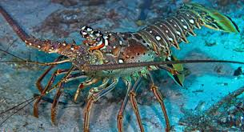

Source: Getty Images.

### DATA AND METHODS

Data was collected from the SBC LTER from 2012 - 2018, as part of an on going study looking at multiple different ecological effects inside of the channel. This data specifically looks at the collection and measurement of the California Spiny Lobster from five different study sites within the SBC LTER. Measurements included the size (in milimeters) of lobsters and population counts annually from 2012 until 2018. All of the analysis was performed in R (version 3.6.1), using the tidyverse, janitor, tidyr, plotly, and DT packages. Statistical signifficance for mean body size between marine protected and non-marine protected areas was calculated using Welch’s t-test with significance set at of 0.05.

### RESULTS

#### **A) Annual Lobster Abundance**

Populations of Calironia Spiny Lobster increased across all sites from 2012 until 2018 **(Figure 1)**. The Marine Protected Area sites of Isla Vista (2012 = 26, 2018 = 946) and Naples (2012 = 6, 2018 = 298) saw significant increases in sampling counts. Carpenteria (2012 = 78, 2018 = 343) and Mohawk (2012 = 83, 2018 = 164) also saw subsatianial increases in population count while Arroyo Quemado (2012 = 38, 2018 = 54) only saw a modest increase in count data.

[figure not shown]

#### **B) Lobster Size Changes**

[figure not shown]

#### **C) MPA vs. Non-MPA Results**

In 2012 the mean area size for MPA sites was 65.69mm while the non-MPA sites had a mean of 75.87mm, a difference of 10.18mm or 15.5% **(Figure 3)** that was statistically significant (two-sided t-test, (t(42.0876871) = -3.2515947, *p* = 0.0022629))) . In the six years after implementation of the MPA status the MPA sites saw a statistically significant increase of 18.42% of mean body size to 77.79 mm in 2018 **(Figure 3)**(two-sided t-test, (t(32.4959062) = 4.687875, *p* = 4.760054810^{-5})). In 2018 there was also a difference in the value of the MPA (77.79mm) and non-MPA sites(73.91mm) that was significant (two-sided t-test, (t(1239.5097551) = 7.307079) *p* = 4.875671310^{-13}).

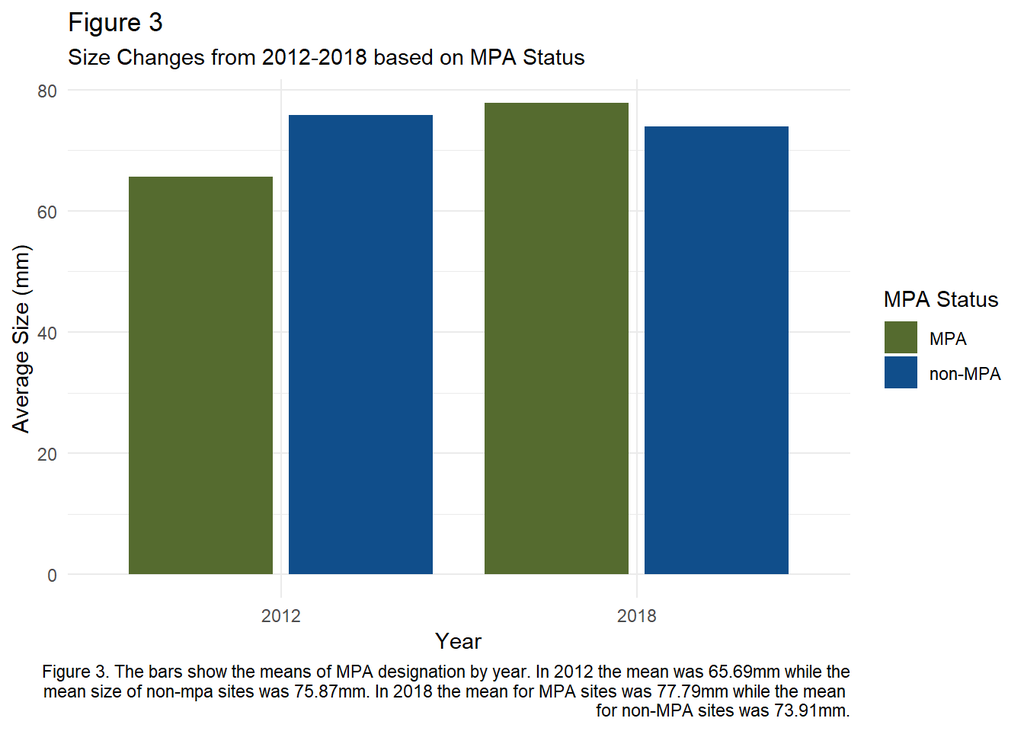

#### Figure 4

[output not shown]

### Citations

1. Reed D. 2019. SBC LTER: Reef: Abundance, size and fishing effort for California Spiny Lobster (Panulirus interruptus), ongoing since 2012. Environmental Data Initiative. https://doi.org/10.6073/pasta/a593a675d644fdefb736750b291579a0. Dataset accessed 10/30/2019.
2. Kay, Matthew C., Hunter S. Lenihan, Carla M. Guenther, Jono R. Wilson, Christopher J. Miller, and Samuel W. Shrout. “Collaborative Assessment of California Spiny Lobster Population and Fishery Responses to a Marine Reserve Network.” Ecological Applications 22, no. 1 (2012): 322–35. https://doi.org/10.1890/11-0155.1.
3. News, Fishermen’s. “Commercial Fishing’s Contribution to Santa Barbara Economy.” Fishermen’s News. Accessed November 13, 2019. https://www.fishermensnews.com/story/2015/12/01/features/commercial-fishings-contribution-to-santa-barbara-economy/364.html.
4. Lester, Sarah E., Benjamin S. Halpern, Kirsten Grorud-Colvert, Jane Lubchenco, Benjamin I. Ruttenberg, Steven D. Gaines, Satie Airamé, and Robert R. Warner. “Biological Effects within No-Take Marine Reserves: A Global Synthesis.” Marine Ecology Progress Series 384 (May 29, 2009): 33–46. https://doi.org/10.3354/meps08029.